# prey_capture_Gasteracantha

Fabian C. Salgado-Roa

9/19/2022

# Introduction

## Load the libraries and standard error function

```r
library(tidyverse)
library(glmmTMB)
library(car)
library(DHARMa)
```

Standard error function

```r
se <- function(x) sd(x)/sqrt(length(x))
```

## Load the datasets

Total dataset

```r
tmp_noNA<-read_csv("data_gasteracantha_field.csv",col_names=T)
```

Because the measures are repeated for each individual, lets create a subset with a single observation to explore association between colour morph and the variables measured

```r
unique_ind <- tmp_noNA %>% distinct(code, .keep_all=T)
```

# Association between the predictors

Check the normality of the variables per colour category

```r
#Web height
hist(unique_ind$Web_height)
```

[output not shown]

```r
qqPlot(unique_ind$Web_height,groups=factor(unique_ind$colour))
```

[output not shown]

```r
#opisthosoma width
hist(unique_ind$opisto_w)
```

[output not shown]

```r
qqPlot(unique_ind$opisto_w,groups=factor(unique_ind$colour))
```

[output not shown]

```r
#web Area
hist(log(unique_ind$web_area+10))
```

[output not shown]

```r
qqPlot(log(unique_ind$web_area+10),groups=factor(unique_ind$colour))
```

[output not shown]

It seems that all the variables are following a normal distribution in every colour category

# Linear models

**Web height**

Run the linear model

```r
mod_webHeight<-lm(Web_height~colour,data=unique_ind)
#plot(mod_webHeight)
```

Check the significance of the predictor

```r
summary(mod_webHeight)
```

```
##
## Call:
## lm(formula = Web_height ~ colour, data = unique_ind)
##
## Residuals:
##     Min      1Q  Median      3Q     Max
## -90.400 -26.210   0.762  30.762  93.790
##
## Coefficients:
##              Estimate Std. Error t value Pr(>|t|)
## (Intercept)   130.400      8.166  15.968   <2e-16 ***
## colourwhite    -4.190      9.674  -0.433    0.666
## colouryellow   -1.162     10.314  -0.113    0.910
## ---
## Signif. codes:  0 '***' 0.001 '**' 0.01 '*' 0.05 '.' 0.1 ' ' 1
##
## Residual standard error: 40.83 on 126 degrees of freedom
## Multiple R-squared:  0.001934,   Adjusted R-squared:  -0.01391
## F-statistic: 0.1221 on 2 and 126 DF,  p-value: 0.8852
```

```r
anova(mod_webHeight)
```

```
## Analysis of Variance Table
##
## Response: Web_height
##            Df Sum Sq Mean Sq F value Pr(>F)
## colour      2    407  203.55  0.1221 0.8852
## Residuals 126 210066 1667.19
```

**Opisthosoma width**

Run the linear model

```r
mod_opistoW<-lm(unique_ind$opisto_w~colour,data=unique_ind)
#plot(mod_opistoW)
```

Check the significance of the predictor

```r
summary(mod_opistoW)
```

```
##
## Call:
## lm(formula = unique_ind$opisto_w ~ colour, data = unique_ind)
##
## Residuals:
##     Min      1Q  Median      3Q     Max
## -3.2229 -0.8017  0.0826  0.8767  2.2771
##
## Coefficients:
##              Estimate Std. Error t value Pr(>|t|)
## (Intercept)    9.6229     0.2640  36.444   <2e-16 ***
## colourwhite    0.5916     0.3245   1.823   0.0712 .
## colouryellow   0.8945     0.3428   2.609   0.0104 *
## ---
## Signif. codes:  0 '***' 0.001 '**' 0.01 '*' 0.05 '.' 0.1 ' ' 1
##
## Residual standard error: 1.294 on 103 degrees of freedom
##   (23 observations deleted due to missingness)
## Multiple R-squared:  0.0625, Adjusted R-squared:  0.04429
## F-statistic: 3.433 on 2 and 103 DF,  p-value: 0.03603
```

```r
anova(mod_opistoW)
```

```
## Analysis of Variance Table
##
## Response: unique_ind$opisto_w
##            Df  Sum Sq Mean Sq F value  Pr(>F)
## colour      2  11.489  5.7445  3.4331 0.03603 *
## Residuals 103 172.350  1.6733
## ---
## Signif. codes:  0 '***' 0.001 '**' 0.01 '*' 0.05 '.' 0.1 ' ' 1
```

**Web area**

Run the linear model

```r
mod_webArea<-lm(log(web_area+10)~colour,data=unique_ind)
#plot(mod_webArea)
```

Check the significance of the predictor

```r
summary(mod_webArea)
```

```
##
## Call:
## lm(formula = log(web_area + 10) ~ colour, data = unique_ind)
##
## Residuals:
##      Min       1Q   Median       3Q      Max
## -1.13781 -0.26759  0.05901  0.32785  0.90343
##
## Coefficients:
##               Estimate Std. Error t value Pr(>|t|)
## (Intercept)   5.903015   0.089639  65.853   <2e-16 ***
## colourwhite  -0.106117   0.106185  -0.999    0.320
## colouryellow  0.008734   0.113217   0.077    0.939
## ---
## Signif. codes:  0 '***' 0.001 '**' 0.01 '*' 0.05 '.' 0.1 ' ' 1
##
## Residual standard error: 0.4482 on 126 degrees of freedom
## Multiple R-squared:  0.01564,    Adjusted R-squared:  1.677e-05
## F-statistic: 1.001 on 2 and 126 DF,  p-value: 0.3704
```

```r
anova(mod_webArea)
```

```
## Analysis of Variance Table
##
## Response: log(web_area + 10)
##            Df  Sum Sq Mean Sq F value Pr(>F)
## colour      2  0.4022 0.20110  1.0011 0.3704
## Residuals 126 25.3110 0.20088
```

*Because we found that the colour morphs differ in their opisthosoma width, we explored if this predictor is associated with prey capture*

**model with negative binomial distribution**

Run the model

```r
capture_opistoW<-glmmTMB(formula=total_preys ~ opisto_w + (1|code) + (1|check),
       family="nbinom2",REML=T,data=tmp_noNA)
```

Check the significance of the predictors

```r
Anova(capture_opistoW)
```

```
## Analysis of Deviance Table (Type II Wald chisquare tests)
##
## Response: total_preys
##           Chisq Df Pr(>Chisq)
## opisto_w 0.5385  1     0.4631
```

**model with zero inflated poisson**

Run the model

```r
capture_opistoW<-glmmTMB(formula=total_preys ~ opisto_w + (1|code) + (1|check),
       zi=~.,
       family="poisson",REML=T,data=tmp_noNA)
```

Check the significance of the predictors

```r
Anova(capture_opistoW)
```

```
## Analysis of Deviance Table (Type II Wald chisquare tests)
##
## Response: total_preys
##           Chisq Df Pr(>Chisq)
## opisto_w 1.0645  1     0.3022
```

```r
Anova(capture_opistoW,component="zi")
```

```
## Analysis of Deviance Table (Type II Wald chisquare tests)
##
## Response: total_preys
##           Chisq Df Pr(>Chisq)
## opisto_w 0.3063  1       0.58
```

**Web area and web height present collinearity**

Run the model

```r
mod_webArea_Heigth<-lm(log(web_area+10)~Web_height,data=unique_ind)
#plot(mod_webArea_Heigth)
```

Check the significance of the predictor

```r
summary(mod_webArea_Heigth)
```

```
##
## Call:
## lm(formula = log(web_area + 10) ~ Web_height, data = unique_ind)
##
## Residuals:
##      Min       1Q   Median       3Q      Max
## -1.08588 -0.26168  0.06801  0.29626  0.93568
##
## Coefficients:
##              Estimate Std. Error t value Pr(>|t|)
## (Intercept) 5.2898942  0.1207005  43.827  < 2e-16 ***
## Web_height  0.0044135  0.0008992   4.908 2.76e-06 ***
## ---
## Signif. codes:  0 '***' 0.001 '**' 0.01 '*' 0.05 '.' 0.1 ' ' 1
##
## Residual standard error: 0.4125 on 127 degrees of freedom
## Multiple R-squared:  0.1594, Adjusted R-squared:  0.1528
## F-statistic: 24.09 on 1 and 127 DF,  p-value: 2.765e-06
```

```r
Anova(mod_webArea_Heigth)
```

```
## Anova Table (Type II tests)
##
## Response: log(web_area + 10)
##             Sum Sq  Df F value    Pr(>F)
## Web_height  4.0998   1   24.09 2.765e-06 ***
## Residuals  21.6134 127
## ---
## Signif. codes:  0 '***' 0.001 '**' 0.01 '*' 0.05 '.' 0.1 ' ' 1
```

# Light differences between sides and colour morphs

**Light measures are bimodal, in consequences we decided to this variable as binary (high or low). This categorization can be explore**

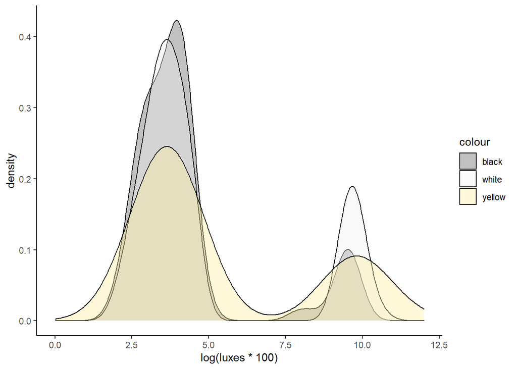

```r
paleta<-c("#636363","#f0f0f0","#ffeda0")

ggplot(data=tmp_noNA, aes(x=log(luxes*100), group=colour, fill=colour)) +
    geom_density(adjust=1.5, alpha=.4) +
    scale_fill_manual(values=paleta)+
    scale_x_continuous(limits=c(0,12))+
    theme_classic()
```

**We explore if there were differences between sides in the exposure to a certain light condition**

Run the model

```r
light_side<-glmmTMB(formula=b_luxes ~ Side+ (1|code) + (1|check),family="binomial",data=tmp_noNA)
```

Check the significance of the predictor

```r
summary(light_side)
```

```
##  Family: binomial  ( logit )
## Formula:          b_luxes ~ Side + (1 | code) + (1 | check)
## Data: tmp_noNA
##
##      AIC      BIC   logLik deviance df.resid
##   1526.5   1548.4   -759.3   1518.5     1774
##
## Random effects:
##
## Conditional model:
##  Groups Name        Variance  Std.Dev.
##  code   (Intercept) 3.891e+00 1.973e+00
##  check  (Intercept) 4.434e-09 6.659e-05
## Number of obs: 1778, groups:  code, 129; check, 3
##
## Conditional model:
##             Estimate Std. Error z value Pr(>|z|)
## (Intercept)  -2.8197     0.2514 -11.217   <2e-16 ***
## Sideventral   1.4594     0.1519   9.608   <2e-16 ***
## ---
## Signif. codes:  0 '***' 0.001 '**' 0.01 '*' 0.05 '.' 0.1 ' ' 1
```

```r
Anova(light_side)
```

```
## Analysis of Deviance Table (Type II Wald chisquare tests)
##
## Response: b_luxes
##       Chisq Df Pr(>Chisq)
## Side 92.305  1  < 2.2e-16 ***
## ---
## Signif. codes:  0 '***' 0.001 '**' 0.01 '*' 0.05 '.' 0.1 ' ' 1
```

We found that the ventral side is more often expose to conditions of high luminosity. Let’s visualize the results

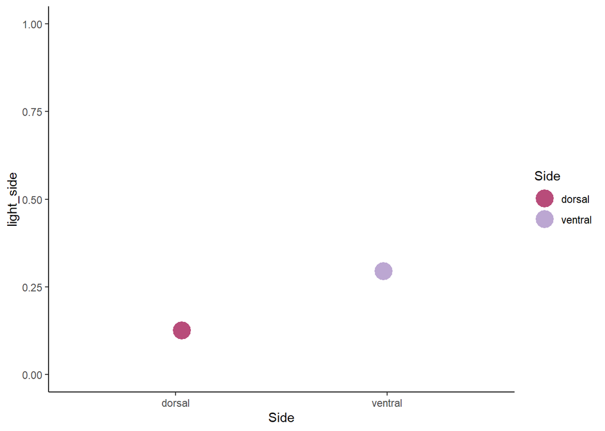

```r
#Predict the values based on the model
tmp_noNA$light_side<-predict(light_side,type="response")
#Colours
paleta_side<-c("#B84C7A","#BCA7D2")
#Plot
ggplot(data = tmp_noNA,aes(x=Side,y=light_side, fill=Side))+
scale_y_continuous(limits=c(0,1))+
     scale_fill_viridis_d( option = "D")+
       scale_fill_manual(values=paleta_side)+
     scale_colour_manual(values=paleta_side)+
     stat_summary(fun = mean,aes(color = Side,group=Side),fun.min = function(x) mean(x) - (2*se(x)),fun.max = function(x) mean(x)+(2*se(x)),geom = "pointrange", position = position_jitterdodge(jitter.width=0.15), size=1.5)+
     theme_classic()
```

**We also tested if the colour morphs differ in which side is expose to the different light environments**

Run the model with yellow and ventral as fixed levels

```r
tmp_noNA$colour<-relevel(as.factor(tmp_noNA$colour),"yellow")
tmp_noNA$Side<-relevel(as.factor(tmp_noNA$Side),"ventral")
colour_light1<-glmmTMB(formula=b_luxes ~ Side*colour + (1|code) + (1|check),family="binomial",data=tmp_noNA)
```

Check the significance of the predictor

```r
summary(colour_light1)
```

```
##  Family: binomial  ( logit )
## Formula:          b_luxes ~ Side * colour + (1 | code) + (1 | check)
## Data: tmp_noNA
##
##      AIC      BIC   logLik deviance df.resid
##   1497.5   1541.4   -740.8   1481.5     1770
##
## Random effects:
##
## Conditional model:
##  Groups Name        Variance Std.Dev.
##  code   (Intercept) 3.85700  1.9639
##  check  (Intercept) 0.00914  0.0956
## Number of obs: 1778, groups:  code, 129; check, 3
##
## Conditional model:
##                        Estimate Std. Error z value Pr(>|z|)
## (Intercept)             -0.5342     0.3531  -1.513  0.13036
## Sidedorsal              -2.6432     0.2871  -9.206  < 2e-16 ***
## colourblack             -1.8288     0.6393  -2.861  0.00423 **
## colourwhite             -1.0586     0.4459  -2.374  0.01759 *
## Sidedorsal:colourblack   1.5460     0.4878   3.169  0.00153 **
## Sidedorsal:colourwhite   1.8725     0.3508   5.338 9.41e-08 ***
## ---
## Signif. codes:  0 '***' 0.001 '**' 0.01 '*' 0.05 '.' 0.1 ' ' 1
```

```r
Anova(colour_light1,type=3)
```

```
## Analysis of Deviance Table (Type III Wald chisquare tests)
##
## Response: b_luxes
##               Chisq Df Pr(>Chisq)
## (Intercept)  2.2882  1   0.130362
## Side        84.7458  1  < 2.2e-16 ***
## colour       9.6436  2   0.008052 **
## Side:colour 29.0236  2  4.984e-07 ***
## ---
## Signif. codes:  0 '***' 0.001 '**' 0.01 '*' 0.05 '.' 0.1 ' ' 1
```

Run the model with black and dorsal as fixed levels

```r
tmp_noNA$colour<-relevel(as.factor(tmp_noNA$colour),"black")
tmp_noNA$Side<-relevel(as.factor(tmp_noNA$Side),"dorsal")
colour_light2<-glmmTMB(formula=b_luxes ~ Side*colour + (1|code) + (1|check),
       family="binomial",data=tmp_noNA)
```

Check the significance of the predictors

```r
summary(colour_light2)
```

```
##  Family: binomial  ( logit )
## Formula:          b_luxes ~ Side * colour + (1 | code) + (1 | check)
## Data: tmp_noNA
##
##      AIC      BIC   logLik deviance df.resid
##   1497.5   1541.4   -740.8   1481.5     1770
##
## Random effects:
##
## Conditional model:
##  Groups Name        Variance Std.Dev.
##  code   (Intercept) 3.85702  1.9639
##  check  (Intercept) 0.00914  0.0956
## Number of obs: 1778, groups:  code, 129; check, 3
##
## Conditional model:
##                          Estimate Std. Error z value Pr(>|z|)
## (Intercept)               -3.4602     0.5918  -5.847 5.02e-09 ***
## Sideventral                1.0973     0.3967   2.766  0.00568 **
## colouryellow               0.2828     0.6974   0.406  0.68507
## colourwhite                1.0967     0.6428   1.706  0.08796 .
## Sideventral:colouryellow   1.5460     0.4878   3.169  0.00153 **
## Sideventral:colourwhite   -0.3265     0.4461  -0.732  0.46422
## ---
## Signif. codes:  0 '***' 0.001 '**' 0.01 '*' 0.05 '.' 0.1 ' ' 1
```

```r
Anova(colour_light2,type=3)
```

```
## Analysis of Deviance Table (Type III Wald chisquare tests)
##
## Response: b_luxes
##               Chisq Df Pr(>Chisq)
## (Intercept) 34.1834  1  5.015e-09 ***
## Side         7.6488  1   0.005681 **
## colour       4.4959  2   0.105617
## Side:colour 29.0235  2  4.984e-07 ***
## ---
## Signif. codes:  0 '***' 0.001 '**' 0.01 '*' 0.05 '.' 0.1 ' ' 1
```

Let’s visualize the results

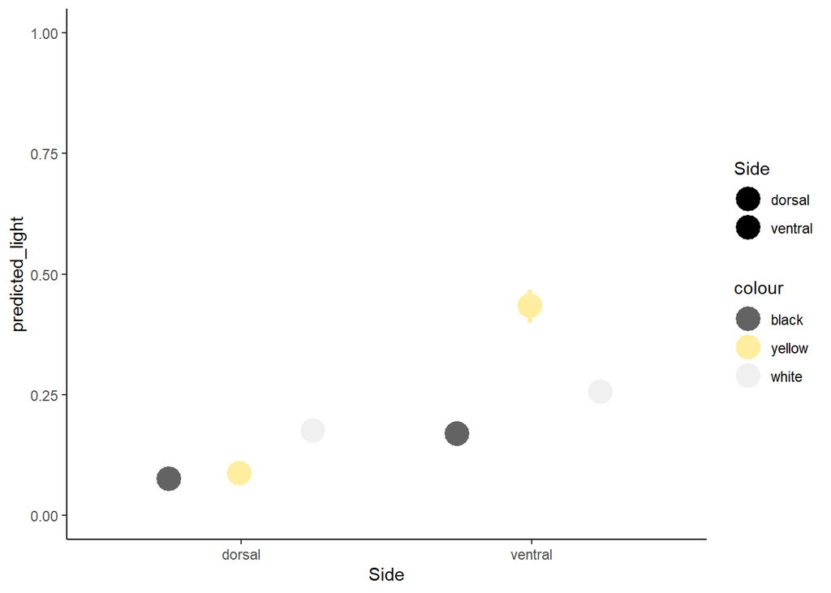

```r
#Predict the values based on the model
tmp_noNA$predicted_light<-predict(colour_light1,type="response")
#Colours
paleta2<-c("#636363","#ffeda0","#f0f0f0")
#Plot
ggplot(data = tmp_noNA,aes(x=Side,y=predicted_light, fill=Side))+
scale_y_continuous(limits=c(0,1))+
     scale_fill_viridis_d( option = "D")+
     #geom_point(data = pop_size,aes(x=colour,y=b_luxes, fill=side, size=value,shape=side), position = position_jitterdodge(jitter.width=0.05),alpha=1)+
       scale_fill_manual(values=paleta2)+
     scale_colour_manual(values=paleta2)+
     stat_summary(fun = mean,aes(color = colour,group=colour),fun.min = function(x) mean(x) - (2*se(x)),fun.max = function(x) mean(x)+(2*se(x)),geom = "pointrange", position = position_jitterdodge(jitter.width=0.15), size=1.5)+
     theme_classic()
```

#Side filtering and analyses (Make this look pretty)

we compared dorsal and ventral light measures of each individual, where the higher measure was considered as open space and the lower measure as vegetation. We did this for everyday of observation. The following code will create a new dataset.

```r
unique_ind2<-data.frame()
for(d in unique(tmp_noNA$day)){
       sub<-tmp_noNA %>% filter(day==d & Time==6.3)
       unique_ind2<-rbind(unique_ind2,sub)
}
side_data<-tibble(code=character(),side=character(),open_space=numeric(),day=numeric())
for(d in unique(unique_ind2$day)){
       filtered_day<-unique_ind2 %>% filter(day==d)
       tmp<-tibble(code=character(),side=character(),open_space=numeric(),day=numeric())
       for(ind in unique(filtered_day$code)) {
              dorsal<-filtered_day %>% filter(code==ind & Side=="dorsal")
              ventral<-filtered_day %>% filter(code==ind & Side=="ventral")
              if(nrow(ventral)==0 | nrow(dorsal)==0){next}
              else if(ventral$luxes>dorsal$luxes){
                     ventral<-tibble(code=ind,side="ventral",open_space=1,day=d)
                     dorsal<-tibble(code=ind,side="dorsal",open_space=0,day=d)
                     tmp<-rbind(tmp,ventral,dorsal)
              } else if(ventral$luxes<dorsal$luxes){
                     ventral<-tibble(code=ind,side="ventral",open_space=0,day=d)
                     dorsal<-tibble(code=ind,side="dorsal",open_space=1,day=d)
                     tmp<-rbind(tmp,ventral,dorsal)
              }
       }
side_data<-rbind(side_data,tmp)
}
```

Let’s evaluate if the new categorization is independent of how the spider position its body towards the different light conditions (High or Low luminosity)

```r
test_association<-chisq.test(factor(unique_ind2$t_luxes),factor(unique_ind2$site_exp))
test_association
```

```
##
##  Pearson's Chi-squared test with Yates' continuity correction
##
## data:  factor(unique_ind2$t_luxes) and factor(unique_ind2$site_exp)
## X-squared = 2.1174, df = 1, p-value = 0.1456
```

Because we did not find association, let’s run an independent model

```r
open_side<-glmmTMB(formula=open_space ~ side+ (1|code),family="binomial",data=side_data) #test which side is most
```

Check the model’s fit

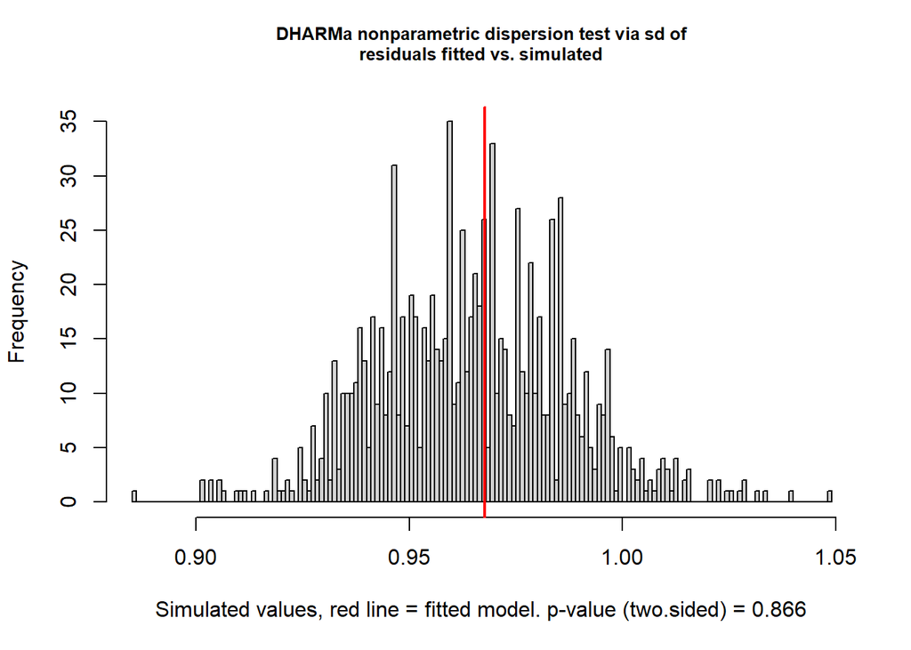

```r
simulationOutput <- simulateResiduals(fittedModel = open_side, n = 1000)
testDispersion(simulationOutput = simulationOutput, alternative ="two.sided")
```

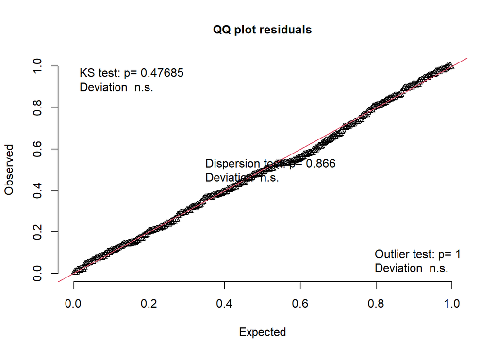

```r
testUniformity(simulationOutput = simulationOutput, alternative ="two.sided")
```

Check the significance of the predictor

```r
summary(open_side)
```

```
##  Family: binomial  ( logit )
## Formula:          open_space ~ side + (1 | code)
## Data: side_data
##
##      AIC      BIC   logLik deviance df.resid
##    392.2    403.2   -193.1    386.2      283
##
## Random effects:
##
## Conditional model:
##  Groups Name        Variance  Std.Dev.
##  code   (Intercept) 8.012e-10 2.831e-05
## Number of obs: 286, groups:  code, 99
##
## Conditional model:
##             Estimate Std. Error z value Pr(>|z|)
## (Intercept)  -0.3822     0.1703  -2.244   0.0248 *
## sideventral   0.7644     0.2409   3.174   0.0015 **
## ---
## Signif. codes:  0 '***' 0.001 '**' 0.01 '*' 0.05 '.' 0.1 ' ' 1
```

```r
Anova(open_side)
```

```
## Analysis of Deviance Table (Type II Wald chisquare tests)
##
## Response: open_space
##       Chisq Df Pr(>Chisq)
## side 10.073  1   0.001505 **
## ---
## Signif. codes:  0 '***' 0.001 '**' 0.01 '*' 0.05 '.' 0.1 ' ' 1
```

# Capture models

##Poisson model

Run the model with white and ventral as fixed levels

```r
tmp_noNA$colour<-relevel(as.factor(tmp_noNA$colour),"white")
tmp_noNA$Side<-relevel(as.factor(tmp_noNA$Side),"ventral")
total_model_poisson<-glmmTMB::glmmTMB(formula=total_preys ~ Side+colour+t_luxes+log(web_area) + (1|code) + (1|check),family="poisson",REML=F,data=tmp_noNA)
```

Test the fit of the model and zero inflation

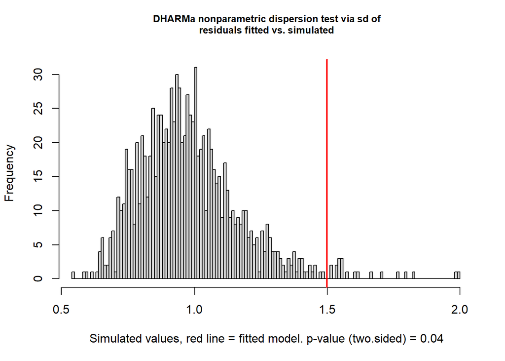

```
##
##  DHARMa nonparametric dispersion test via sd of residuals fitted vs.
##  simulated
##
## data:  simulationOutput
## dispersion = 1.5266, p-value = 0.04
## alternative hypothesis: two.sided
```

```r
simulationOutput <- simulateResiduals(fittedModel = total_model_poisson, n = 1000)
testDispersion(simulationOutput = simulationOutput, alternative ="two.sided")
```

```r
testUniformity(simulationOutput = simulationOutput, alternative ="two.sided")
```

```
## DHARMa:testOutliers with type = binomial may have inflated Type I error rates for integer-valued distributions. To get a more exact result, it is recommended to re-run testOutliers with type = 'bootstrap'. See ?testOutliers for details
```

[figure not shown]

[output not shown]

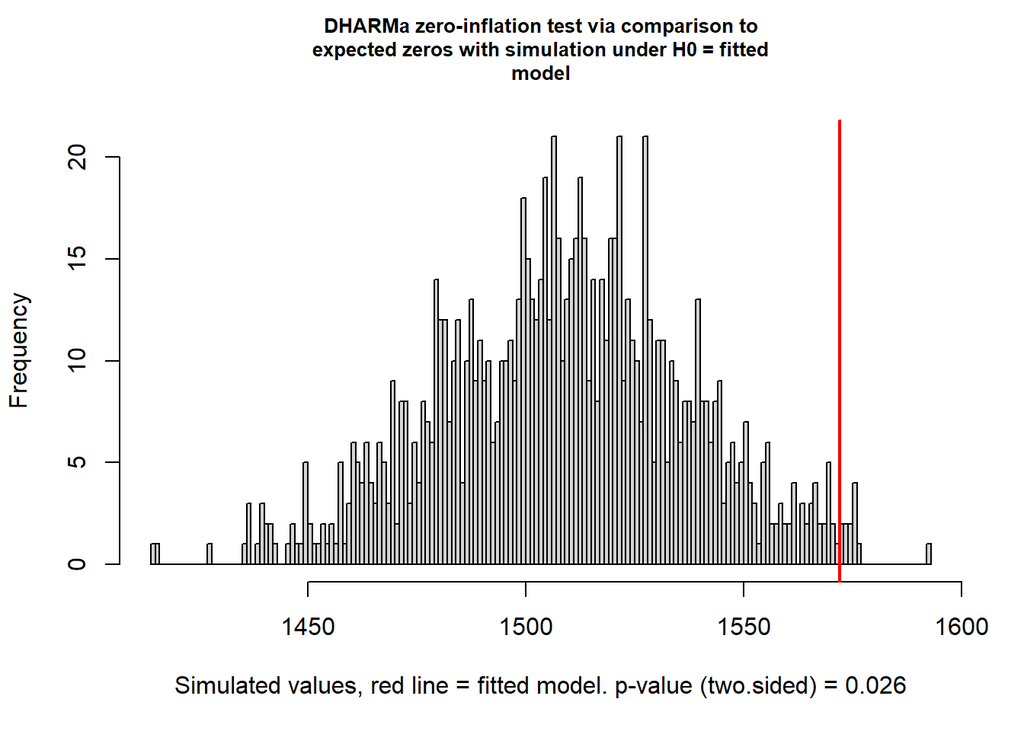

```
##
##  DHARMa zero-inflation test via comparison to expected zeros with
##  simulation under H0 = fitted model
##
## data:  simulationOutput
## ratioObsSim = 1.0416, p-value = 0.026
## alternative hypothesis: two.sided
```

```r
testZeroInflation(simulationOutput = simulationOutput, alternative ="two.sided")
```

Because this model has zero inflation, dispersion and no uniformity; its is necessary to run a zero-inflation model to check is it fits better

```r
total_model_pzi<-glmmTMB::glmmTMB(formula=total_preys ~ colour+Side+t_luxes+log(web_area) + (1|code) + (1|check),zi=~.,family="poisson",REML=F,data=tmp_noNA)
```

Test the fit of the new model and zero inflation

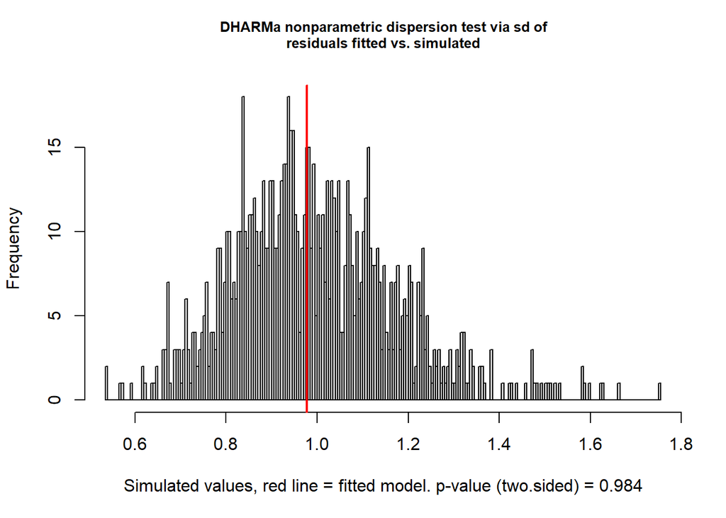

```
##
##  DHARMa nonparametric dispersion test via sd of residuals fitted vs.
##  simulated
##
## data:  simulationOutput
## dispersion = 0.98562, p-value = 0.984
## alternative hypothesis: two.sided
```

```r
simulationOutput <- simulateResiduals(fittedModel = total_model_pzi, n = 1000)
testDispersion(simulationOutput = simulationOutput, alternative ="two.sided")
```

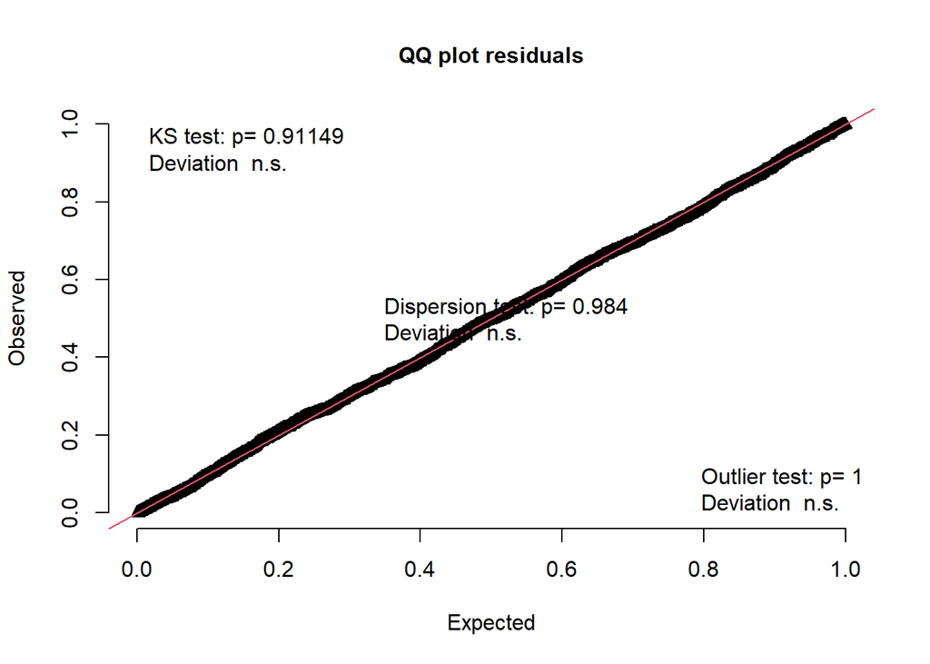

```
##
##  One-sample Kolmogorov-Smirnov test
##
## data:  simulationOutput$scaledResiduals
## D = 0.013301, p-value = 0.9115
## alternative hypothesis: two-sided
```

```r
testUniformity(simulationOutput = simulationOutput, alternative ="two.sided")
```

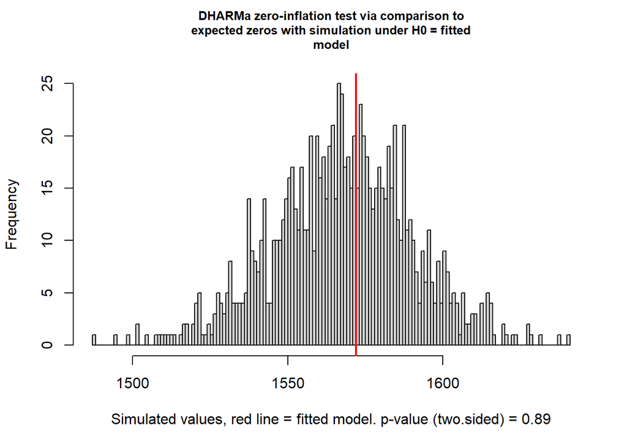

```
##
##  DHARMa zero-inflation test via comparison to expected zeros with
##  simulation under H0 = fitted model
##
## data:  simulationOutput
## ratioObsSim = 1.0026, p-value = 0.89
## alternative hypothesis: two.sided
```

```r
testZeroInflation(simulationOutput = simulationOutput, alternative ="two.sided")
```

This model seems to be ok, let’s now check the significance of the predictors

```r
summary(total_model_pzi)
```

```
##  Family: poisson  ( log )
## Formula:          total_preys ~ colour + Side + t_luxes + log(web_area) + (1 |
##     code) + (1 | check)
## Zero inflation:               ~.
## Data: tmp_noNA
##
##      AIC      BIC   logLik deviance df.resid
##   1682.9   1770.7   -825.5   1650.9     1762
##
## Random effects:
##
## Conditional model:
##  Groups Name        Variance  Std.Dev.
##  code   (Intercept) 3.190e-01 5.648e-01
##  check  (Intercept) 3.255e-09 5.706e-05
## Number of obs: 1778, groups:  code, 129; check, 3
##
## Zero-inflation model:
##  Groups Name        Variance Std.Dev.
##  code   (Intercept) 0.06063  0.2462
##  check  (Intercept) 0.02915  0.1707
## Number of obs: 1778, groups:  code, 129; check, 3
##
## Conditional model:
##                Estimate Std. Error z value Pr(>|z|)
## (Intercept)   -3.004197   1.816736  -1.654   0.0982 .
## colourblack   -0.005214   0.367110  -0.014   0.9887
## colouryellow  -0.016472   0.310669  -0.053   0.9577
## Sidedorsal    -0.003787   0.238478  -0.016   0.9873
## t_luxeslow     0.098386   0.294865   0.334   0.7386
## log(web_area)  0.419130   0.292796   1.432   0.1523
## ---
## Signif. codes:  0 '***' 0.001 '**' 0.01 '*' 0.05 '.' 0.1 ' ' 1
##
## Zero-inflation model:
##               Estimate Std. Error z value Pr(>|z|)
## (Intercept)     0.2118     2.0637   0.103   0.9183
## colourblack     0.3111     0.3936   0.790   0.4294
## colouryellow   -0.1430     0.3373  -0.424   0.6715
## Sidedorsal     -0.3659     0.2872  -1.274   0.2027
## t_luxeslow     -0.5939     0.3397  -1.748   0.0804 .
## log(web_area)   0.2700     0.3346   0.807   0.4198
## ---
## Signif. codes:  0 '***' 0.001 '**' 0.01 '*' 0.05 '.' 0.1 ' ' 1
```

```r
Anova(total_model_pzi)
```

```
## Analysis of Deviance Table (Type II Wald chisquare tests)
##
## Response: total_preys
##                Chisq Df Pr(>Chisq)
## colour        0.0030  2     0.9985
## Side          0.0003  1     0.9873
## t_luxes       0.1113  1     0.7386
## log(web_area) 2.0491  1     0.1523
```

```r
Anova(total_model_pzi,component="zi")
```

```
## Analysis of Deviance Table (Type II Wald chisquare tests)
##
## Response: total_preys
##                Chisq Df Pr(>Chisq)
## colour        1.4667  2    0.48030
## Side          1.6226  1    0.20273
## t_luxes       3.0558  1    0.08045 .
## log(web_area) 0.6508  1    0.41983
## ---
## Signif. codes:  0 '***' 0.001 '**' 0.01 '*' 0.05 '.' 0.1 ' ' 1
```

**We did not find any association between the predictor and the prey capture rate**

##Negative binomial model

Run the model with white and ventral as fixed levels

```r
total_model_nb<-glmmTMB::glmmTMB(formula=total_preys ~ colour+Side+t_luxes+log(web_area) + (1|code) + (1|check),family="nbinom2",REML=F,data=tmp_noNA)
```

Test the fit of the model and zero inflation

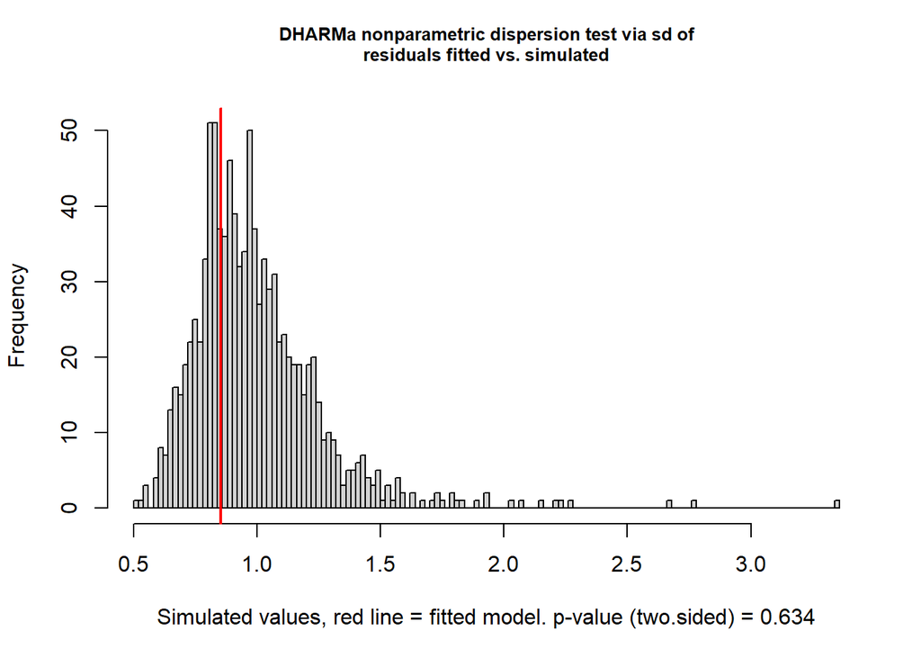

```
##
##  DHARMa nonparametric dispersion test via sd of residuals fitted vs.
##  simulated
##
## data:  simulationOutput
## dispersion = 0.86011, p-value = 0.634
## alternative hypothesis: two.sided
```

```r
simulationOutput <- simulateResiduals(fittedModel = total_model_nb, n = 1000)
testDispersion(simulationOutput = simulationOutput, alternative ="two.sided")
```

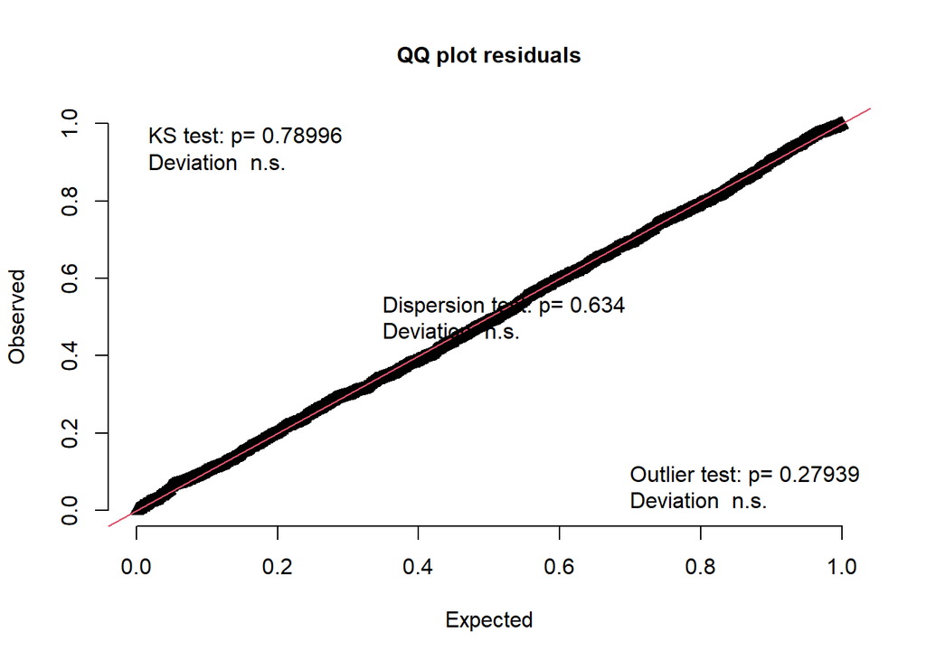

```
##
##  One-sample Kolmogorov-Smirnov test
##
## data:  simulationOutput$scaledResiduals
## D = 0.015446, p-value = 0.79
## alternative hypothesis: two-sided
```

```r
testUniformity(simulationOutput = simulationOutput, alternative ="two.sided")
```

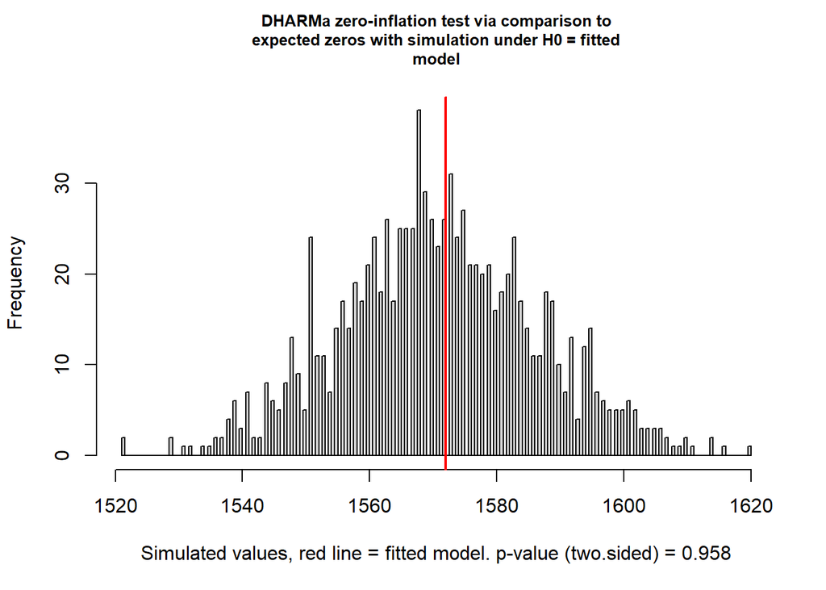

```
##
##  DHARMa zero-inflation test via comparison to expected zeros with
##  simulation under H0 = fitted model
##
## data:  simulationOutput
## ratioObsSim = 1.0006, p-value = 0.958
## alternative hypothesis: two.sided
```

```r
testZeroInflation(simulationOutput = simulationOutput, alternative ="two.sided")
```

This model seems to be ok, let’s now check the significance of the predictors

```r
summary(total_model_nb)
```

```
##  Family: nbinom2  ( log )
## Formula:          total_preys ~ colour + Side + t_luxes + log(web_area) + (1 |
##     code) + (1 | check)
## Data: tmp_noNA
##
##      AIC      BIC   logLik deviance df.resid
##   1683.9   1733.3   -833.0   1665.9     1769
##
## Random effects:
##
## Conditional model:
##  Groups Name        Variance  Std.Dev.
##  code   (Intercept) 3.445e-01 0.5869796
##  check  (Intercept) 1.771e-08 0.0001331
## Number of obs: 1778, groups:  code, 129; check, 3
##
## Dispersion parameter for nbinom2 family (): 0.259
##
## Conditional model:
##               Estimate Std. Error z value Pr(>|z|)
## (Intercept)    -3.5174     1.2828  -2.742  0.00611 **
## colourblack    -0.2407     0.2664  -0.903  0.36631
## colouryellow    0.1171     0.2217   0.528  0.59719
## Sidedorsal      0.3144     0.1614   1.948  0.05136 .
## t_luxeslow      0.5752     0.2209   2.604  0.00920 **
## log(web_area)   0.1661     0.2116   0.785  0.43242
## ---
## Signif. codes:  0 '***' 0.001 '**' 0.01 '*' 0.05 '.' 0.1 ' ' 1
```

```r
Anova(total_model_nb)
```

```
## Analysis of Deviance Table (Type II Wald chisquare tests)
##
## Response: total_preys
##                Chisq Df Pr(>Chisq)
## colour        1.6595  2   0.436161
## Side          3.7966  1   0.051356 .
## t_luxes       6.7831  1   0.009202 **
## log(web_area) 0.6163  1   0.432421
## ---
## Signif. codes:  0 '***' 0.001 '**' 0.01 '*' 0.05 '.' 0.1 ' ' 1
```

To create the plot fothe results, we have to predict the values under the model

```r
#Predict values to plot
tmp_noNA$response_nb<-predict(total_model_nb,type="response")
```

**With this, we can create two plots, one per side in order to make easy to visualize the results**

###Plot dorsal

Create subset

```r
plot_dorsal <- tmp_noNA %>% filter(Side=="dorsal")
plot_dorsal$colour<-relevel(as.factor(plot_dorsal$colour),"black")
```

Plot the results

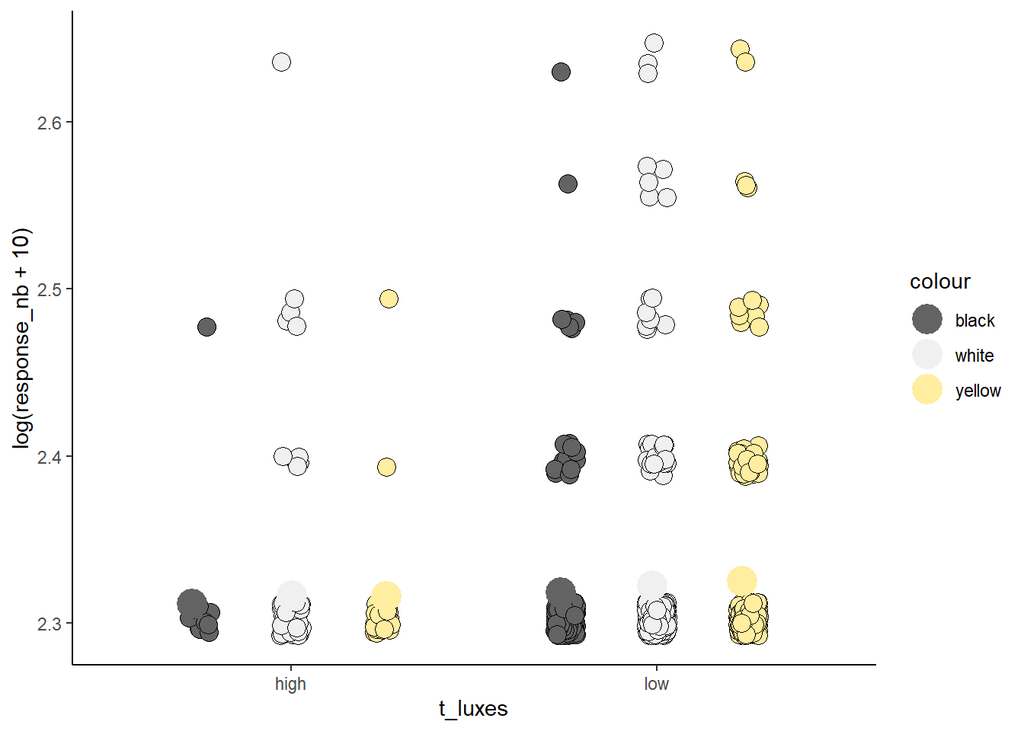

```r
#Colours
paleta2<-c("#636363","#f0f0f0","#ffeda0")
#plot
ggplot(data = plot_dorsal,aes(x=t_luxes,y=log(response_nb+10), fill=colour))+
     scale_fill_viridis_d( option = "D")+
     geom_point(data = plot_dorsal,aes(x=t_luxes,y=log(total_preys+10), fill=colour),shape = 21,size=4, position = position_jitterdodge(jitter.width=0.15,jitter.height=0.01),alpha=1.0)+
       scale_fill_manual(values=paleta2)+
     scale_colour_manual(values=paleta2)+
     stat_summary(fun = mean,aes(color = colour,group=colour),fun.min = function(x) mean(x) - 2*se(x),fun.max = function(x) mean(x)+2*se(x),geom = "pointrange", position = position_jitterdodge(jitter.width=0.15), size=1.5)+
     theme_classic()
```

###Plot ventral

Create subset

```r
plot_ventral <- tmp_noNA %>% filter(Side=="ventral")
plot_ventral$colour<-relevel(as.factor(plot_ventral$colour),"black")
```

Plot the results

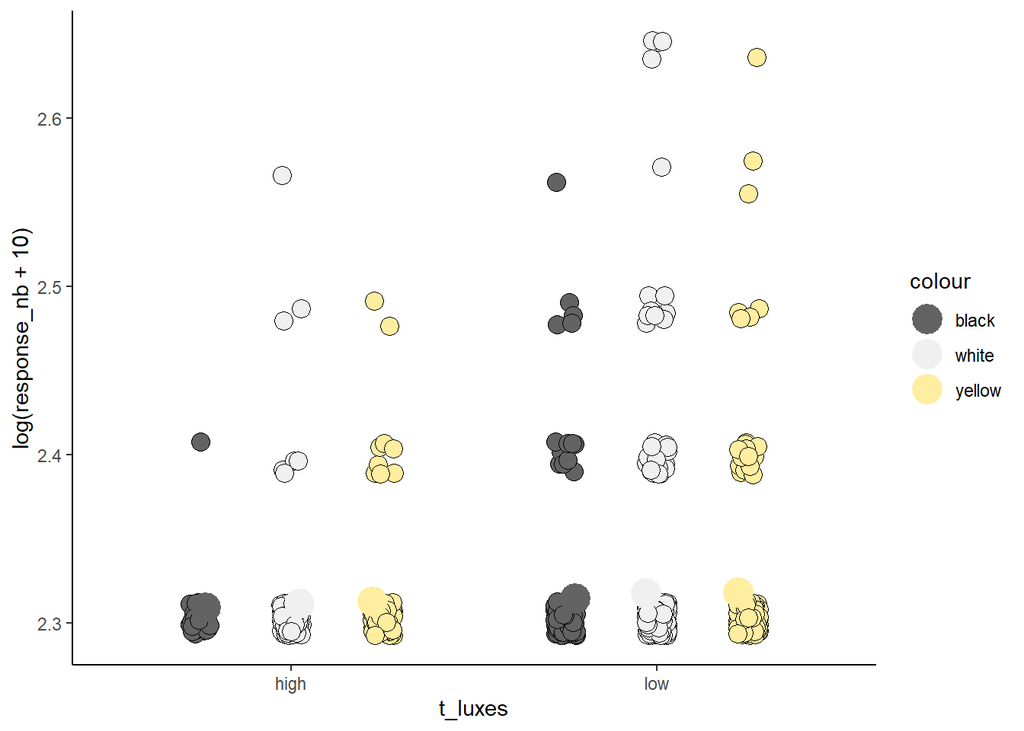

```r
#Colours
paleta2<-c("#636363","#f0f0f0","#ffeda0")
#plot
ggplot(data = plot_ventral,aes(x=t_luxes,y=log(response_nb+10), fill=colour))+
     scale_fill_viridis_d( option = "D")+
     geom_point(data = plot_ventral,aes(x=t_luxes,y=log(total_preys+10), fill=colour),shape = 21,size=4, position = position_jitterdodge(jitter.width=0.15,jitter.height=0.01),alpha=1.0)+
       scale_fill_manual(values=paleta2)+
     scale_colour_manual(values=paleta2)+
     stat_summary(fun = mean,aes(color = colour,group=colour),fun.min = function(x) mean(x) - 2*se(x),fun.max = function(x) mean(x)+2*se(x),geom = "pointrange", position = position_jitterdodge(jitter.width=0.15), size=1.5)+
     theme_classic()
```